# MNIST Machine Learning

```python
#Supress warnings because they contain file paths
import warnings
warnings.filterwarnings('ignore')
```

```python
#Import keras
import tensorflow as tf
import sklearn.decomposition
import pandas as pd
from tensorflow import keras
import numpy as np
import pandas as pd
from matplotlib import pyplot as plt
from sklearn.preprocessing import StandardScaler
from sklearn.decomposition import PCA

%matplotlib inline
```

**Prompt:**

Unsupervised learning. Perform a principle component analysis on the MNIST data set. Produce various plots in the dimensionally reduced space using the principle components.

**Answer:**

The MNIST dataset is comprised of data corresponding to images of handwritten digits with a training set of 60,000 rows and a test set of 10,000 rows. This dataset is often used for people to learn how to use machine learning learning techniques without having to perform extensive preprocessing (Le Cun, Cortes, and Burges, 2018). PCA, or principle component analysis, is often used in exploratory analysis of a dataset, and is used to separate data into components that accounts for variability in data. PCAs are created by the decomposition of eigenvalues or singular value of a data matrix. The first principle component is meant to explain the most of the variance, with each subsequential component explaining additional variance, but with the restraint that it is orthogonal (perpendicular) to the preceding components (Einasto, Liivamägi, Saar, Einasto & Tempel, 2011). To perform a PCA on this dataset, I regularize the data, split it into train and test datasets, scale the data, shape the data, and produce different representations of the PCA. I will plot the PCA with corresponding label colors, additional and cumulative variance explained, explore different numbers of components, and map a 3-component PCA in three dimensions.

After loading the necessary packages (importantly, primarily using scikit-learn to process the data, NumPy to shape the data, and TensorFlow/Keras to load the data), I load the MNIST dataset and splitting it into train and test data sets. After splitting the train and test data, I divide the data by 255 to regularize it. This routine scales the data between [0,1], which stabilizes and speeds up any optimization.

```python
#Make train and test sets
mnist = tf.keras.datasets.mnist

(x_train, y_train),(x_test, y_test) = mnist.load_data()
x_train, x_test = x_train / 255.0, x_test / 255.0
```

Since the PCA needs to take the data in the format (60,000, 784), I reshape the data to fit this specification. Subsequently, I select a two-component PCA, and fit the data with two dimensions with different colors.

```
(60000, 28, 28)
```

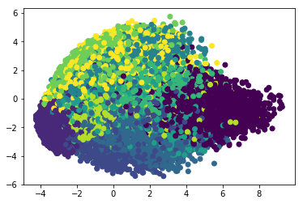

```python
#Reshape data to make it suitable for PCA
print(x_train.shape)
train_xs = np.reshape(x_train, (x_train.shape[0], x_train.shape[1] * x_train.shape[2]))

# Fit the PCA with 2 components
mod = PCA(n_components=2)
mod.fit(train_xs)

# Transform train_xs according to the model
train_xst = mod.transform(train_xs)

# Plot two dimensions, such that the color corresponds to the label
plt.scatter(train_xst[:,0], train_xst[:,1], c = list(y_train))
```

```
Text(0,0.5,'Additional explained variance')
```

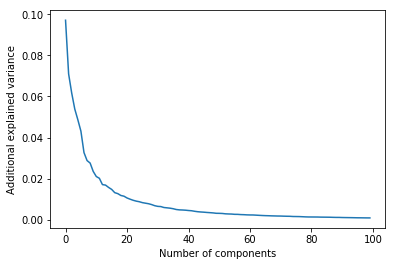

```python
#Make a PCA with 100 components and fit it to a model
pca = PCA(100)
fullpca = pca.fit(train_xs)

#Plot additional explained variance with every additional component
plt.plot(fullpca.explained_variance_ratio_)
plt.xlabel('Number of components')
plt.ylabel('Additional explained variance')
```

Next, I plot the cumulative amount of variance explained by each component. Added together, the first 100 components explain close to .9 of the variance in the dataset, but additional explained variance levels off at around 20 principal components.

```
Text(0,0.5,'Cumulative explained variance')
```

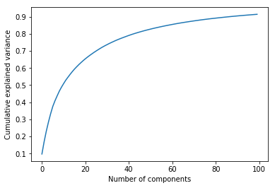

```python
#Plot cumulative explanation with 100 components
pca = PCA(100)
pca_full = pca.fit(train_xs)

plt.plot(np.cumsum(pca_full.explained_variance_ratio_))
plt.xlabel('Number of components')
plt.ylabel('Cumulative explained variance')
```

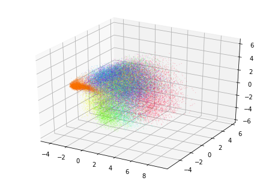

```python
#Load the 3D Plot
from mpl_toolkits.mplot3d import Axes3D

#Plot 3 Components
mod = PCA(n_components=3)
mod.fit(train_xs)

#Transform train_xs appropriately
train_xst = mod.transform(train_xs)

#Plot the principle components
fig = plt.figure()
ax = Axes3D(fig)
ax.scatter(train_xst[:,0], train_xst[:,1], train_xst[:,2], cmap=plt.get_cmap('gist_rainbow', 10), c = list(y_train), s = 0.01)
plt.show()

#MatPlot Lib Documentation Referenced
```

**Prompt:**

Explain either the mathematics or the intuition behind the kernel trick used in SVMs and how it allows to express a non-linear classifier through a linear classifier in a higher-dimensional space.

**Answer:**

The kernel trick is used when our data is in 'n' dimensional space, which is not separable into linearly boundaries by a Support Vector Classifier. As 'real-life' data is often not linearly separable, the use of kernel functions is key for defining boundaries. Optimal decision boundaries are created from the maximum possible distance between points in different classes in the linear case, but when data is in a hyperplane with 'n' dimensions, the constraints of the decision boundary changes.

Instead, if the decision boundary in a hyperplane that separates classes has different weights in a vector v, it is necessary to maximize the distance from this vector to the closest points (the support vectors). The kernel trick avoids a step of mapping linear functions to higher dimensional space because these functions can be expressed instead as the dot product of data in the higher space instead of operating on the data itself (Kandan 2017). This mapping is one of the implications of Mercer's theorem, which states that the inner products on a finite dimensional space can be characterized by linear operators (Thickstun 2017). The use of these inner products (i.e. the "kernel trick") considerably increases computational efficiency of separating data into n-dimensional space and allows the kernel functions of choice to designate more appropriate decision boundaries around the data.

The most common types of kernels used are linear, polynomial, radial basis function (RBF), and sigmoid kernel. The different kinds of kernel are specified as follows (d, γ, r are kernel parameters):

**Linear Kernel**:

$$k(X,Y) = X^TY + c$$

**Polynomial kernel**: This function is often used in image processing (where γ>0 and d is the polynomial degree of the data)

$$K(X,Y)= (x^T y + c)^d$$

**Radial Basis function (RBF) Kernel**: Often this kind of kernel function is used in situations where not much context about the data is known (where γ>0):

$$K(X,Y)=(−γ⋅‖X−Y‖^2)$$

**Sigmoid Kernel:** This kernel function operates similarly to a sigmoid function in a logistic regression.

$$K(X,Y)=tanh(γ⋅X^TY+r)$$

In the following figures, I will map these different kernel functions and create different decision boundaries to describe the MNIST data.

Reference: (Souza, 2010)

First, I load the necessary packages from scikit-learn to create instances of SVM.

```python
#Load relevant SVM packages
from sklearn import svm
from sklearn.svm import SVC

from matplotlib import pyplot as plt
%matplotlib inline


#Fit the RBF kernel to the data
classifier = svm.SVC(kernel='rbf')
classifier.fit(train_xst, y_train)

#SkLearn documentation referred to
```

```
SVC(C=1.0, cache_size=200, class_weight=None, coef0=0.0,
  decision_function_shape='ovr', degree=3, gamma='auto', kernel='rbf',
  max_iter=-1, probability=False, random_state=None, shrinking=True,
  tol=0.001, verbose=False)
```

**Prompt:**

Practical: Build a linear support vector classifier in Python for the MNIST classification task. Use various kernels to build a better non-linear classifier.

**Answer:**

[figure not shown]

```python
# Make a PCA with different kernels

mnist = tf.keras.datasets.mnist

#Load the data
(x_train, y_train),(x_test, y_test) = mnist.load_data()
x_train, x_test = x_train / 255.0, x_test / 255.0

#Reshape the data
train_xs = np.reshape(x_train, (x_train.shape[0], x_train.shape[1] * x_train.shape[2]))

# For faster computation, I created a subset of the data
selector = np.random.randint(train_xs.shape[0], size= 3000)
train_xs_subset = train_xs[selector, :]
y_train_subset = y_train[selector]

# Then I made a PCA with two components
model = PCA(n_components=2)
model.fit(train_xs_subset)
train_xs_subset_t = model.transform(train_xs_subset)

# Created a meshgrid with different subsets
def make_meshgrid(x, y, h=.02):
    x_min, x_max = x.min() - 1, x.max() + 1
    y_min, y_max = y.min() - 1, y.max() + 1
    xx, yy = np.meshgrid(np.arange(x_min, x_max, h),
                         np.arange(y_min, y_max, h))
    return xx, yy

# Plotted the contours of the decision boundaries
def plot_contours(ax, clf, xx, yy, **params):
    Z = clf.predict(np.c_[xx.ravel(), yy.ravel()])
    Z = Z.reshape(xx.shape)
    out = ax.contourf(xx, yy, Z, **params)
    return out

#Designated the SVM Models to be fit to the mesh grid
SVMmodels = (svm.SVC(kernel='linear'),
          svm.SVC(kernel='rbf'),
          svm.SVC(kernel='poly', degree=2),
          svm.SVC(kernel='sigmoid'))

SVMmodels = (clf.fit(train_xs_subset_t, y_train_subset) for clf in SVMmodels)


# Titled the plots
titles = ('SVC (Linear kernel)',
          'SVC (RBF kernel)',
          'SVC (Degree 3 polynomial kernel) ',
          'SVC (Sigmoid kernel)')

# Set-up the grid for plotting
fig, sub = plt.subplots(2, 2)
plt.subplots_adjust(wspace=0.4, hspace=0.4)

X0, X1 = train_xs_subset_t[:, 0], train_xs_subset_t[:, 1]
xx, yy = make_meshgrid(X0, X1)

#Create the Graph
for clf, title, ax in zip(SVMmodels, titles, sub.flatten()):
    plot_contours(ax, clf, xx, yy,
                  cmap=plt.cm.coolwarm, alpha=0.8)
    ax.scatter(X0, X1, c=y_train_subset, cmap=plt.cm.coolwarm, s=20, edgecolors='k')
    ax.set_xlim(xx.min(), xx.max())
    ax.set_ylim(yy.min(), yy.max())
    ax.set_xticks(())
    ax.set_yticks(())
    ax.set_title(title)

plt.show()

#(Plot Template from Sci-kit Learn Developers, 2018)
```

**Prompt:**

By applying the chain law of derivatives to the objective function of a neural network, derive the back propagation algorithm.

**Answer:**

At the core of the back propagation algorithm, it takes the cost function, C and takes the partial derivative with respect to any weight (w) or bias (b) in the network (∂C/∂w). The back propogation algorithm in practice tells us how quickly the cost (accuracy) changes with changes to the weights and biases in the neural network. Back propagation calculates an error at the end of the calculation and then adjusts each weight in a network in proportion to that weight's contribution to the overall error. In adjusting or penalizing these weights iteratively, the algorithm is able to adjust weights so that the neural network creates good predictions.

The backpropagation algorithm can be thought of a way to apply the chain rule to find the derivatives of the cost function with respect to any variable (bias or weight)in a nested equation.

To illustrate this principle, in the case of a forward propagation function, if A1, A2, and A3 are all activation functions at different layers of a neural network, a function could look like this: $$f(x)=A1(A2(A3(x)))$$

If the derivative of f(x) is taken with respect to x, using the chain rule, we can calculate $$f′(x)=f′(A1)⋅A1′(A2)⋅A2′(A3)⋅A3′(x)$$

To take the derivative with respect to $A2$, you put $A2$ as a placeholder in the function, pretending that $A2(A3(x))$ is a constant, and then find the derivative with respect to $A2$ normally. This can help us investigate the influence a variable has on the total output, in this case, the cost function of a neural network for backpropagation.

In order to figure out how much weights are contributing to error and by how much, several functions need to be defined.

**Defining Weighted Input** $$ L(X,W) = XW $$ $$ L'(X) = W $$ $$ L'(W) = X $$ **ReLu Activation Function** $$ R(L) = max(0,L)$$ $$ R'(L) = 0; L<0$$ $$ R'(L) = 1; L>0$$ **Cost Function** $$ C (\hat{y})= (1/2)(\hat{y} - y)^2$$ $$ C'(\hat{y}) = (\hat{y} - y) $$

If a network had a single neuron, total cost could then be described as: $$ Cost=C(R(L(X,W))) $$

Which, if you apply the chain rule to it, becomes: $$ C′(W)=C′(R)⋅R′(L)⋅L′(W)=(ŷ −y)⋅R′(L)⋅X $$

**Chain of events in the neural network:**

The input layer to the hidden layer: $$ L_{h} = X * W_{h} $$

The hidden layer activation function: $$ H = R(L_{h}) $$

The hidden layer to the last layer before the output: $$ L_{0} = H * W_{0} $$

The last input to the output function: $$ O = R(L_{0}) $$

First, we'll consider a neural network with one hidden layer. In an example where $W_{0}$ is the last weight before the output layer, we can see the derivative with respect to this last layer by the following:

$$C′(W_{0})=C′(ŷ )⋅ŷ ′(L_{0})⋅L′_{0}(W_{0})=(ŷ −y)⋅R′(L_{0})⋅H $$

Then we can find out the derivatives even further back in our function by applying this chain rule recursively (where we get to a function with the $W_{h}$'s term if H signifies the number of hidden layers and ${h}$ is the index).

$$C′(W_{h})=C′(ŷ )⋅O′(L_{0})⋅L′_{0}(H)⋅H′(L_{h})⋅L′_{h}(W_{h})=(ŷ −y)⋅R′(L_{0})⋅W_{0}⋅R′(L_{h})⋅X$$

Similarly, if we wanted to find out the cost relative to last output layer $L_{o}$ (i.e. how the last inputs effected the cost of the network), we would calculate:

$$C′(L_{0})=(ŷ −y)⋅R′(L_{0})$$

We would then calculate the cost of the inputs relative to any hidden layer, $H$ with respect to the hidden layer input, $L_{h}$.

$$C′(L_{h})=(ŷ −y)⋅R′(L_{0})⋅W_{0}⋅R′(L_{h})$$

This formula is commonly simplified to:

$$ E_{h}=E_{0}⋅W_{0}⋅R′(L_{h}) $$

This formula shows us that we are calculating a layer's error and then passing along the weight's errors back across the previous layer, updating the weights every time while using the derivative of cost function.

Finally, simplifying even further, we can take the previous function and substitute in the new $E_{0}$ term: $$C′(W_{0})=(ŷ −y)⋅R′(L_{0})⋅H $$

Turns into:

$$C′(W_{o})=E_{0}⋅H$$

Thus, in order to find out the derivative of cost with respect to any weight, we can multiply the current layer's error and the current layer's input.

$$C′(w)=CurrentLayersError⋅CurrentLayersInput$$

We see these principles implemented in the form of matrix multiplication and NumPy operations in the next section.

Referred to: ML Cheatsheet (2017)

**Prompt:**

Coding. [20 points] Implement from scratch, as a Python class, a feedforward neural network with 1 hidden layer of 100 hidden units merely using basic linear algebra computations in Numpy. Based on your derivation of back-propagation, or otherwise, implement a train method based on stochastic or batch gradient descent. Test your implementation on the MNIST classification task.

First, I do some data cleaning and data reshaping in order to prepare the data for the neural network. Online resources (see references) were used to inspire my approach (Weisberg 2018).

```python
#Designate the number of digits
digits = 10

#Load the data again
mnist = tf.keras.datasets.mnist

#Split into train and test
(x_train, y_train),(x_test, y_test) = mnist.load_data()

#Regularize the data
x_train, x_test = x_train / 255.0, x_test / 255.0

#Reshape the data
x_trains = np.reshape(x_train, (x_train.shape[0], x_train.shape[1] * x_train.shape[2]))
x_tests = np.reshape(x_test, (x_test.shape[0], x_test.shape[1] * x_test.shape[2]))

#Hotcode the y variable so it can go into the model
y_trains = np.array(pd.get_dummies(y_train).iloc[:,0])
y_tests = np.array(pd.get_dummies(y_test).iloc[:,0])

m = 60000
m_test = 10000

# Finally get to the reshaped train and test data
X_train, X_test = x_trains.T, x_tests.T
y_train, y_test = y_trains.reshape(1,60000), y_tests.reshape(1,10000)
```

I then create the loss function, based on the differences observed between Y and Y hat (Y_pred).

```python
#Create a loss function
def compute_loss (Y, Y_pred):
    L_sum = np.sum(np.multiply(Y, np.log(Y_pred)))
    m = Y.shape[1]
    L = -(1/m) * L_sum
    return L
```

I also create a ReLU function, which returns input negative values as 0. However, for this exercise, I will use a sigmoid function (see next).

```python
#Define ReLU function
def ReLU(x):
    return x * (x > 0)
```

Finally, I create the sigmoid function (used in logistic regression), which shapes the data into an S-curve, returning values between 0 and 1.

```python
#Define sigmoid function
def sig(x):
    sig = 1 / (1 + np.exp(-x))
    return sig
```

```python
#Designate X and Y
X = X_train
Y = y_train
```

```python
#Define parameters, including dimensions and learning rate
dimx = X_train.shape[0]
#Define a small learning rate to prevent from large steps and erratic behavior in the model
learning_rate = .05
#Hidden layer definition
nl = 100
```

```python
#Initialize the weights
weight1 = np.random.randn(nl, dimx)
weight2 = np.random.randn(digits, nl)
```

```python
#Define the biases
bias1 = np.zeros((nl, 1))
bias2 = np.zeros((digits, 1))
```

Using matrix multiplication (@) and transposition (T) in NumPy, I implement the gradient descent algorithm and specify a multi-category loss function. The implementation has a modest training error, and possibly could be made more accurate by designating different depths of hidden layers or using the more commonly ReLu activation function.

```python
#Implement backpropagation algorithm
#Specify the intermediate values
for i in range(1000):
    L1 = (weight1 @ X) + bias1
    A1 = sig(L1)
    L2 = (weight2 @ A1) + bias2
    A2 = np.exp(L2) / np.sum(np.exp(L2), axis=0)

#Compute the loss function
    cost = compute_loss(Y, A2)

    derL2 = A2-Y
    derW2 = (1./m) * (derL2 @ A1.T)
    derb2 = (1./m) * np.sum(derL2, axis=1, keepdims=True)
    derA1 = (weight2.T @ derL2)

#Use sigmoid function
    derL1 = derA1 * sig(L1) * (1 - sig(L1))
    derW1 = (1./m) * (derL1 @ X.T)
    derb1 = (1./m) * np.sum(derL1, axis=1, keepdims=True)
    weight1 = weight1 - derW1 * learning_rate
    weight2 = weight2 - derW2 * learning_rate
    bias2 = bias2 - derb2 * learning_rate
    bias1 = bias1 - derb1 * learning_rate

#Run and print out the number of epochs and final cost
    if (i % 100 == 0):
        print("epoch", i, "cost: ", cost)

print("final cost:", cost)
```

```
epoch 0 cost:  7.565122651524356
epoch 100 cost:  5.986954061751997
epoch 200 cost:  5.596291735709095
epoch 300 cost:  5.232127045994736
epoch 400 cost:  4.81011738575411
epoch 500 cost:  4.269293109057646
epoch 600 cost:  3.7516506532154543
epoch 700 cost:  3.44089079395316
epoch 800 cost:  3.2574126761020934
epoch 900 cost:  3.1389978201800735
final cost: 3.0510154083383614
```

**Prompt:**

Use TensorFlow (potentially using a frontend such as tflearn or keras) to implement a 2 layer neural network with 1200 and 1200 hidden units. Use RELU activation function instead of sigmoids, as well as add regularisation methods such as dropout to produce a model which has a test error of below 2%. 10 points will be given for building a working network and 5 point for achieving the benchmark.

**Answer:**

To build a two-layer neural network with a test error of below 2%, I use the Keras package on top of Tensorflow to construct a sequential model. In order to achieve accuracy, I add a dropout layer (a technique with adjustable parameters) used to prevent overfitting of the neural network, a softmax layer, used for multi-category classification, and a ReLu activation function. The ReLu (rectified linear unit) activation function is used, specified as R(z) = max (0, z). This activation function differs from the sigmoid activation function, as the d the ReLu activation function takes all negative inputs and plots them to 0 (Sharma, 2017).

```python
#Build a RNN neural network now
#Import keras
from tensorflow import keras
```

```python
#Load the data again
mnist = tf.keras.datasets.mnist

#Split into train and test
(x_train, y_train),(x_test, y_test) = mnist.load_data()

#Regularize the data
x_train, x_test = x_train / 255.0, x_test / 255.0

#One-hotcode y
y_train_hotcode = pd.get_dummies(y_train)
```

```python
#Create an RNN with Adam Optimizer and Categorical Crossentropy

model = keras.Sequential([
    keras.layers.Flatten(input_shape=(28, 28)),
    keras.layers.Dense(1200, activation=tf.nn.relu),
    keras.layers.Dropout(0.5),
    keras.layers.Dense(1200, activation=tf.nn.relu),
    keras.layers.Dense(10, activation=tf.nn.softmax)
])

model.compile(optimizer=tf.train.AdamOptimizer(),
          loss='categorical_crossentropy',
          metrics=['accuracy'])

model.fit(x_train, y_train_hotcode,
          batch_size=128,
          epochs=10,
          verbose=1,
          validation_split = 0.2,
          shuffle=True)
#Made with reference to official Keras documentation
```

```
Train on 48000 samples, validate on 12000 samples
```

```
<tensorflow.python.keras.callbacks.History at 0x1a33f60b38>
```

```python
#Validate on the test set
y_test_hotcode = pd.get_dummies(y_test)

metrics = model.evaluate(x_test, y_test_hotcode, verbose=1)
print("Test loss:", metrics[0])
print("Test accuracy:", metrics[1])
```

```
Test loss: 0.07068578312017926
Test accuracy: 0.9813
```

**Prompt:**

Data Science Challenge. This is a problem to challenge you. Any reasonable attempt will grant you full points. For this problem (and only for this problem) you are allowed to work in groups of up to 3 students handing in the same solution. The idea is that you use this last problem as a competition between your peers or peer groups in the course. It is a continuation of problem 3.c. Using a high-level frontend for tensorflow such as tflearn or keras, try to improve your classifier by means of deeper networks and/or convolution layers which are readily available as plug&play building blocks. Depending on interest and time we can use the more challenging CIFAR10 data set for this last part as opposed to the simpler to predict MNIST dataset. In the latter case, it would also make sense to use GPUs.

**Answer:**

For the data science challenge, a convolutional neural network is used to classify the MNIST data. Convolutional neural networks have similaries to the previously used relational neural networks with weights and biases, but assume image data inputs. Convolutional neural networks, as demonstrated below, have a convolutional layer, a pooling layer and a fully-connected layer. Our neural network performed at a high accuracy after using two convolutional layers, two Max Pooling layers, and an Adam Optimizer to dynamically alter the learning rate. Max pooling layers use the greatest value of clusters of neurons at the prior layer. Just like other kinds of neural networks, the fully-connected layer does the primary executive "work" of the neural network, with access to the all the activations in the layer before (Karpathy 2018). A ReLu activation function was used, and a softmax layer was also used, as it is a categorical classification task. We were able to achieve 98.8% accuracy over running the convolutional neural network over five epochs. When validating against the test set, we achieved 98.71% test accuracy and .039 test loss.

```python
#Make a convolutional neural network
#Data Science Challenge
x_train = x_train.reshape(x_train.shape[0], x_train.shape[1], x_train.shape[2], 1)
x_test = x_test.reshape(x_test.shape[0], x_test.shape[1], x_test.shape[2], 1)
y_train_h = pd.get_dummies(y_train)
model = tf.keras.Sequential()
model.add(tf.keras.layers.Conv2D(15, kernel_size=(3, 3),
                 activation='relu',
                 input_shape=(28,28,1)))
model.add(tf.keras.layers.MaxPooling2D(pool_size=(2, 2)))
model.add(tf.keras.layers.Conv2D(20, (3, 3), activation='relu'))
model.add(tf.keras.layers.MaxPooling2D(pool_size=(2, 2)))
model.add(tf.keras.layers.Flatten())
model.add(tf.keras.layers.Dense(120, activation='relu'))
model.add(tf.keras.layers.Dropout(0.2))
model.add(tf.keras.layers.Dense(84, activation='relu'))
model.add(tf.keras.layers.Dropout(0.2))
model.add(tf.keras.layers.Dense(10, activation='softmax'))
model.compile(optimizer=tf.train.AdamOptimizer(),
          loss='categorical_crossentropy',
          metrics=['accuracy'])
model.fit(x_train, y_train_h,
          batch_size=128,
          epochs=5,
          verbose=1,
          validation_split = 0.2,
          shuffle=True)

#Made with reference to official Keras documentation
```

```
Train on 48000 samples, validate on 12000 samples
```

```
<tensorflow.python.keras.callbacks.History at 0x1a54f65c88>
```

```python
#Validate on the test set
y_test_h = pd.get_dummies(y_test)
metrics = model.evaluate(x_test, y_test_h, verbose=1)
print("Test loss:", metrics[0])
print("Test accuracy:", metrics[1])
```

```
Test loss: 0.03977394223157608
Test accuracy: 0.9871
```

**References**:

UPDATED QUESTION : PCA before SVM - is it really necessary? (n.d.). Retrieved January 11, 2019, from https://www.researchgate.net/post/UPDATED_QUESTION_PCA_before_SVM-is_it_really_necessary

Weisberg, J. (n.d.). Building a Neural Network from Scratch: Part 1. Retrieved January 11, 2019, from https://jonathanweisberg.org/post/A Neural Network from Scratch - Part 1/

Jason Brownlee. (n.d.). Gentle Introduction to the Adam Optimization Algorithm for Deep Learning. Retrieved January 11, 2019, from https://machinelearningmastery.com/adam-optimization-algorithm-for-deep-learning/

Sharma, S. (n.d.). Activation Functions: Neural Networks – Towards Data Science. Retrieved January 11, 2019, from https://towardsdatascience.com/activation-functions-neural-networks-1cbd9f8d91d6

CS231n Convolutional Neural Networks for Visual Recognition. (n.d.). Retrieved January 10, 2019, from http://cs231n.github.io/convolutional-networks/

Kernel Functions for Machine Learning Applications – César Souza. (n.d.). Retrieved January 10, 2019, from http://crsouza.com/2010/03/17/kernel-functions-for-machine-learning-applications/#linear

Dataflair Team. (2017). Kernel Functions-Introduction to SVM Kernel & Examples - DataFlair. Retrieved January 10, 2019, from https://data-flair.training/blogs/svm-kernel-functions/

Kernel Functions-Introduction to SVM Kernel & Examples - DataFlair. (n.d.). Retrieved January 10, 2019, from https://data-flair.training/blogs/svm-kernel-functions/

Thickstun, J. (n.d.). MERCER’S THEOREM. Retrieved from https://homes.cs.washington.edu/~thickstn/docs/mercer.pdf

Toolkits — Matplotlib 2.2.2 documentation. (n.d.). Retrieved January 13, 2019, from https://matplotlib.org/mpl_toolkits/index.html

Julien Mairal. (n.d.). Examples of Kernels and Unsupervised Learning. Retrieved from http://lear.inrialpes.fr/people/harchaoui/teaching/2013-2014/ensl/m2/lecture5.pdf

Kandan, H. (2017). Understanding the kernel trick. – Towards Data Science. Retrieved January 10, 2019, from https://towardsdatascience.com/understanding-the-kernel-trick-e0bc6112ef78

Einasto, M., Liivamägi, L. J., Saar, E., Einasto, J., Tempel, E., Tago, E., & Martínez, V. J. (2011). SDSS DR7 superclusters Principal component analysis. Retrieved from http://atmos.physic.ut.ee/

ML Cheatsheet documentation. Retrieved January 12, 2019, from https://ml-cheatsheet.readthedocs.io/en/latest/backpropagation.html

MNIST handwritten digit database, Yann LeCun, Corinna Cortes and Chris Burges. (n.d.). Retrieved January 10, 2019, from http://yann.lecun.com/exdb/mnist/